# Fitting spatiotemporal models

## What we’ve learned so far

- Time series can be useful for identifying structure, improving precision, and accuracy of forecasts
- Modeling multivariate time series
  - e.g. MARSS() function, with each observed time series mapped to a single discrete state
- Using DFA
  - Structure determined by factor loadings

## Response generally the same variable (not separate species)

- Making inference about population as a whole involves jointly modeling both time series

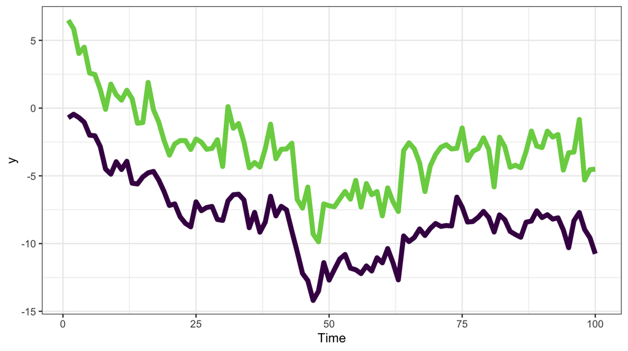

## Lots of time series -> complicated covariance matrices

- For unconstrained covariance matrices, the number of covariance matrix parameters = \(m*(m+1)/2\)
  - problematic for m > 5 or so
- MARSS solutions: diagonal matrices or ‘equalvarcov’
- DFA runs into same issues with estimating unconstrained \(R\) matrix

## Potential problems with both the MARSS and DFA approach

- Sites separated by large distances may be grouped together
- Sites close to one another may be found to have very different dynamics

## Are there biological mechanisms that may explain this?

- Puget Sound Chinook salmon
  - 21 populations generally cluster into 2-3 groups based on genetics
  - Historically large hatchery programs
- Hood canal harbor seals
  - Visited by killer whales

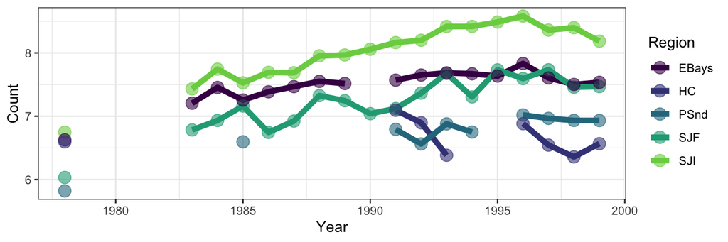

## Motivation of explicitly including spatial structure

- Adjacent sites can be allowed to covary
- Estimated parameters greatly reduced to 2-5

## Types of spatial data

Point referenced data (aka geostatistical)

- Typically 2-D, but could be 1-D or 3-D (depth, altitude)
- May be fixed station or random (e.g. trawl surveys)

Point pattern data

- Spatially referenced based on outcomes (e.g. presence)
- Inference focused on describing clustering (or not)

Areal data

- Locations occur in blocks
- counties, management zones, etc.

## Areal data: Seattle Council Districts

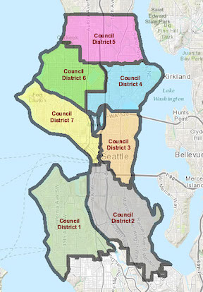

## Most of our data is geostatistical

Challenges